# METABRIC: Análisis de Cáncer de Mama

Andrea Zurita, Leo Alza, Lucia Güeto y Paula Cubero

# 1 Introducción

El cáncer es una de las principales causas de mortalidad a nivel mundial y representa un **problema sanitario, social y científico de primer orden**. Dentro de este grupo de enfermedades, el **cáncer de mama** constituye con diferencia el tipo de cáncer más frecuente en mujeres, mientras que otros tumores como los **sarcomas** representan una fracción muy reducida de los casos diagnosticados.

En este trabajo se emplea el dataset **Breast Cancer Gene Expression Profiles (METABRIC)**, disponible públicamente en Kaggle, que recoge información clínica y molecular de miles de pacientes con cáncer de mama. Este conjunto de datos permite estudiar de forma integrada variables demográficas, clínicas y de supervivencia, ofreciendo una base sólida para el análisis de factores pronósticos.

Entre las variables analizadas destacan:

- **age_at_diagnosis**: edad del paciente en el momento del diagnóstico.
- **overall_survival_months**: meses de supervivencia general. Duración desde el momento de la intervención hasta el fallecimiento.
- **tumor_size**: tamaño del tumor medido mediante técnicas de imagen.
- **chemotherapy**: Si el paciente recibió o no quimioterapia.

## 1.1 Planteamiento de hipótesis

### 1.1.1 Hipotesis 1: Edad y cirugía realizada al paciente

Se comparará la **edad de diagnóstico** de los pacientes que se sometieron a una **mastectomía** frente a aquellos que no tuvieron que realizársela y **conservaron el pecho**. El objetivo es evaluar si existe una relación entre la **edad del diagnóstico del paciente** y el **tipo de cirugía**.

- **Hipótesis nula(H₀):** Las edades medias de las mujeres que se hicieron mastectomía y de las que conservaron el pecho son iguales.
- **Hipótesis alternativa (H₁):** Las edades medias de las mujeres que se hicieron mastectomía y de las que conservaron el pecho son diferentes.

### 1.1.2 Hipotesis 2: Tamaño de tumor y tipo de cirugía

Se comparará el **tamaño del tumor** con el **tipo de cirugía** realizada para ver si el tamaño de este determina la decisión de hacer una mastectomía o no, o es otro parámetro el determinante del tipo de cirugía que se realiza.

- **Hipótesis nula(H₀):** El tamaño medio del tumor de las mujeres con mastectomía es igual al tamaño medio de las que conservaron el pecho.
- **Hipótesis alternativa (H₁):** El tamaño medio del tumor de las mujeres con mastectomía es mayor al tamaño medio de las que conservaron el pecho.

### 1.1.3 Hipótesis 3: Quimioterapia y meses de supervivencia

Se comparará los meses de supervivencia de las mujeres en función de si se han sometido o no a quimioterapia.

- **Hipótesis nula(H₀):** Los meses de supervivencia no están relacionados significativamente con la administración de quimioterapia.
- **Hipótesis alternativa (H₁):** Los meses de supervivencia están relacionados significativamente con la administración de quimioterapia.

En conjunto, este estudio pretende **evaluar la validez de estas hipótesis utilizando datos reales**, aplicando métodos estadísticos descriptivos, inferenciales y análisis de supervivencia, con el objetivo de comprender mejor los factores clínicos que influyen en el pronóstico del cáncer de mama.

Tabla 1: Vista preliminar de las 10 primeras lineas del dataset METABRIC

| patient_id | age_at_diagnosis | type_of_breast_surgery | cancer_type | cancer_type_detailed | cellularity | chemotherapy | pam50_._claudin.low_subtype | cohort | er_status_measured_by_ihc | er_status | neoplasm_histologic_grade | her2_status_measured_by_snp6 | her2_status | tumor_other_histologic_subtype | hormone_therapy | inferred_menopausal_state | integrative_cluster | primary_tumor_laterality | lymph_nodes_examined_positive | mutation_count | nottingham_prognostic_index | oncotree_code | overall_survival_months | overall_survival | pr_status | radio_therapy | X3.gene_classifier_subtype | tumor_size | tumor_stage | … |
| --- | --- | --- | --- | --- | --- | --- | --- | --- | --- | --- | --- | --- | --- | --- | --- | --- | --- | --- | --- | --- | --- | --- | --- | --- | --- | --- | --- | --- | --- | --- |
| 0 | 75.65 | MASTECTOMY | Breast Cancer | Breast Invasive Ductal Carcinoma |  | 0 | claudin-low | 1 | Positve | Positive | 3 | NEUTRAL | Negative | Ductal/NST | 1 | Post | 4ER+ | Right | 10 | NA | 6.044 | IDC | 140.50000 | 1 | Negative | 1 | ER-/HER2- | 22 | 2 | … |
| 2 | 43.19 | BREAST CONSERVING | Breast Cancer | Breast Invasive Ductal Carcinoma | High | 0 | LumA | 1 | Positve | Positive | 3 | NEUTRAL | Negative | Ductal/NST | 1 | Pre | 4ER+ | Right | 0 | 2 | 4.020 | IDC | 84.63333 | 1 | Positive | 1 | ER+/HER2- High Prolif | 10 | 1 | … |
| 5 | 48.87 | MASTECTOMY | Breast Cancer | Breast Invasive Ductal Carcinoma | High | 1 | LumB | 1 | Positve | Positive | 2 | NEUTRAL | Negative | Ductal/NST | 1 | Pre | 3 | Right | 1 | 2 | 4.030 | IDC | 163.70000 | 0 | Positive | 0 |  | 15 | 2 | … |
| 6 | 47.68 | MASTECTOMY | Breast Cancer | Breast Mixed Ductal and Lobular Carcinoma | Moderate | 1 | LumB | 1 | Positve | Positive | 2 | NEUTRAL | Negative | Mixed | 1 | Pre | 9 | Right | 3 | 1 | 4.050 | MDLC | 164.93333 | 1 | Positive | 1 |  | 25 | 2 | … |
| 8 | 76.97 | MASTECTOMY | Breast Cancer | Breast Mixed Ductal and Lobular Carcinoma | High | 1 | LumB | 1 | Positve | Positive | 3 | NEUTRAL | Negative | Mixed | 1 | Post | 9 | Right | 8 | 2 | 6.080 | MDLC | 41.36667 | 0 | Positive | 1 | ER+/HER2- High Prolif | 40 | 2 | … |
| 10 | 78.77 | MASTECTOMY | Breast Cancer | Breast Invasive Ductal Carcinoma | Moderate | 0 | LumB | 1 | Positve | Positive | 3 | NEUTRAL | Negative | Ductal/NST | 1 | Post | 7 | Left | 0 | 4 | 4.062 | IDC | 7.80000 | 0 | Positive | 1 | ER+/HER2- High Prolif | 31 | 4 | … |
| 14 | 56.45 | BREAST CONSERVING | Breast Cancer | Breast Invasive Ductal Carcinoma | Moderate | 1 | LumB | 1 | Positve | Positive | 2 | LOSS | Negative | Ductal/NST | 1 | Post | 3 | Right | 1 | 4 | 4.020 | IDC | 164.33333 | 1 | Positive | 1 |  | 10 | 2 | … |
| 22 | 89.08 | BREAST CONSERVING | Breast Cancer | Breast Mixed Ductal and Lobular Carcinoma | Moderate | 0 | claudin-low | 1 | Positve | Positive | 2 | NEUTRAL | Negative | Mixed | 1 | Post | 3 | Left | 1 | 1 | 4.058 | MDLC | 99.53333 | 0 | Negative | 1 |  | 29 | 2 | … |
| 28 | 86.41 | BREAST CONSERVING | Breast Cancer | Breast Invasive Ductal Carcinoma | Moderate | 0 | LumB | 1 | Positve | Positive | 3 | GAIN | Negative | Ductal/NST | 1 | Post | 9 | Right | 1 | 4 | 5.032 | IDC | 36.56667 | 0 | Negative | 1 | ER+/HER2- High Prolif | 16 | 2 | … |
| 35 | 84.22 | MASTECTOMY | Breast Cancer | Breast Invasive Lobular Carcinoma | High | 0 | Her2 | 1 | Negative | Positive | 2 | LOSS | Negative | Lobular | 0 | Post | 3 | Left | 0 | 5 | 3.056 | ILC | 36.26667 | 0 | Negative | 0 | ER+/HER2- High Prolif | 28 | 2 | … |

Los datos tienen 1904 filas y 693 columnas.

# 2 Materiales y Métodos

Para realizar los análisis se han usado R (R Core Team 2024) con las librerias dplyr (Wickham et al. 2023) y ggplot (Wickham et al. 2025; Wickham 2016). Para la creación de este informe hemos utilizado el paquete knitr (Xie 2025, 2015, 2014) y pandoc.

# 3 Análisis y Resultados

## 3.1 Análisis de edad de diagnóstico vs tipo de cirugía

```r
datos_filtrados_1 <- mis_datos %>%   # Creamos un nuevo objeto llamado "datos_filtrados_1" a partir del dataset "mis_datos" y usamos pipe para encadenar las operaciones

  filter(!is.na(type_of_breast_surgery),
         type_of_breast_surgery != "")%>%  # Filtramos aquellas filas donde la columna "type_of_breast_surgery" no sea NA (un valor que no existe) y que no esté vacío.
  select(2, 3) # Seleccionamos solo las columnas 2 y 3 del dataset
```

Tabla 1. Estadísticas descriptivas de la edad al diagnóstico

| n | Media | Mediana | SD | Mínimo | Máximo |
| --- | --- | --- | --- | --- | --- |
| 1882 | 61.14659 | 61.825 | 12.97072 | 21.93 | 96.29 |

```
##      n    Media Mediana       SD Mínimo Máximo
## 1 1882 61.14659  61.825 12.97072  21.93  96.29
```

### 3.1.1 Gráficos de resultados de edad de diagnóstico y tipo de cirugía

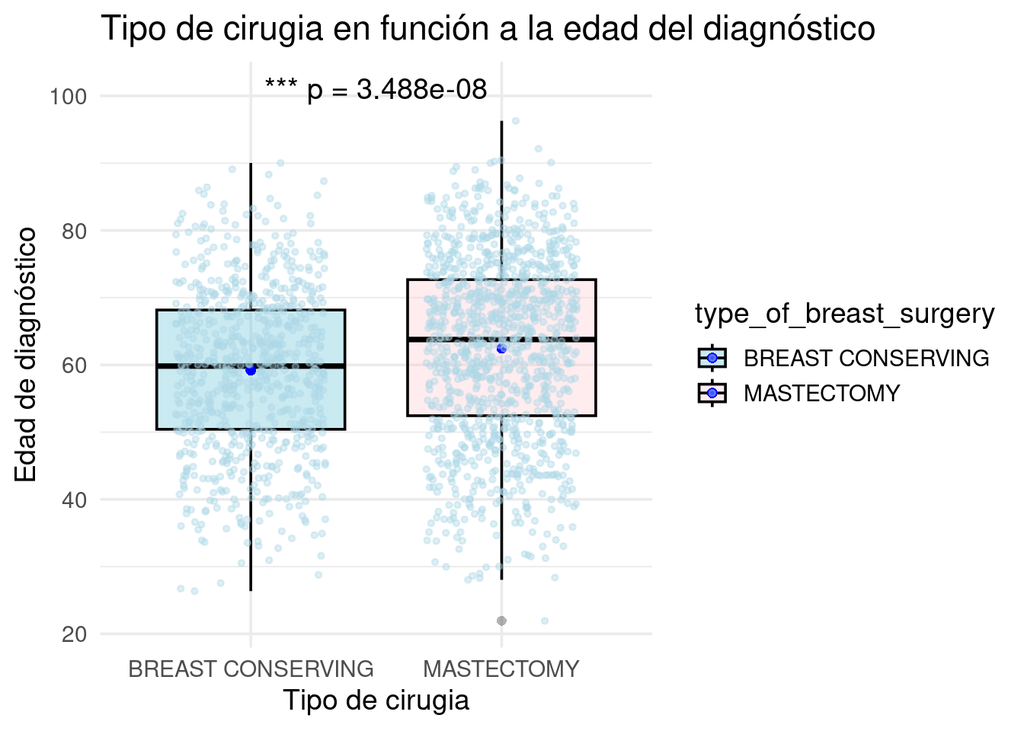

Figura 1. Boxplot de la edad de diagnóstico según el tipo de cirugía

```r
ggplot(datos_filtrados_1,
       aes(x = type_of_breast_surgery,
           y = age_at_diagnosis,
           fill = type_of_breast_surgery)) +
  geom_boxplot(outlier.shape = 16, alpha = 0.3, color="black") +
  stat_summary(fun = mean, geom = "point", shape = 16, size = 2, color = "blue") +
  geom_jitter(color= "#ADD8E6",width = 0.3, alpha = 0.4, size = 1) +
  scale_fill_manual(values = c("#4DBBD5", "pink")) +
  labs(
    x = "Tipo de cirugia",
    y = "Edad de diagnóstico",
    title = "Tipo de cirugia en función a la edad del diagnóstico"
  ) +
  theme_minimal(base_size = 14) +
  theme(legend.position = "right") +
  annotate("text",
           x = 1.5,
           y = max(datos_filtrados_1$age_at_diagnosis, na.rm = TRUE) * 1.05,
           label = "*** p = 3.488e-08",
           size = 5)
```

Las mujeres que no tuvieron que realizarse la mastectomía presentaron una edad de diagnóstico menor que aquellas que tuvieron que realizarse la cirugía presentando una edad de diagnóstico más elevada.

Ahora vamos a analizar las medias realizando el **T-test**. Nuestra variable numérica será la edad y la variable categórica es el tipo de cirugía. Primero extraemos las columnas *age_at_diagnostic* y *type_of_breast_surgery* como vectores

```
##
##  Welch Two Sample t-test
##
## data:  edad by cirugia
## t = -5.5403, df = 1721.6, p-value = 3.488e-08
## alternative hypothesis: true difference in means between group BREAST CONSERVING and group MASTECTOMY is not equal to 0
## 95 percent confidence interval:
##  -4.452701 -2.124327
## sample estimates:
## mean in group BREAST CONSERVING        mean in group MASTECTOMY
##                        59.17732                        62.46584
```

Como el p valor sale 3.488 × 10<sup>-8</sup> , menor a 0,05 , existen **diferencias significativas** entre la edad de diagnóstico y el tipo de cirugía realizada.

## 3.2 Análisis de tamaño del tumor y tipo de cirugía

Tabla 2. Estadísticas descriptivas del tamaño del tumor

| n | Media | Mediana | SD | Mínimo | Máximo |
| --- | --- | --- | --- | --- | --- |
| 1882 | 26.16529 | 23 | 15.03869 | 1 | 182 |

```
##      n    Media Mediana       SD Mínimo Máximo
## 1 1882 26.16529      23 15.03869      1    182
```

```
##
##  Welch Two Sample t-test
##
## data:  tamaño_tumor by cirugia
## t = -12.175, df = 1865.9, p-value < 2.2e-16
## alternative hypothesis: true difference in means between group BREAST CONSERVING and group MASTECTOMY is not equal to 0
## 95 percent confidence interval:
##  -9.006474 -6.507339
## sample estimates:
## mean in group BREAST CONSERVING        mean in group MASTECTOMY
##                        21.53108                        29.28798
```

### 3.2.1 Gráficos de resultados de tipo de tumor y tipo de cirugía

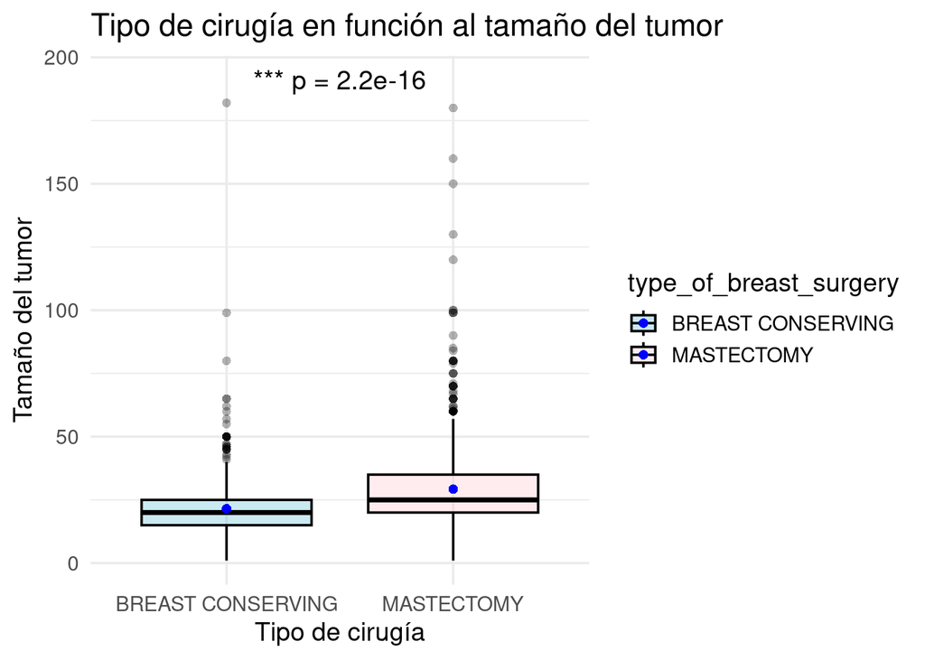

Figura 2. Boxplot de tipo de cirugía según el tamaño del tumor

## 3.3 Análisis de quimioterapia y Supervivencia en meses

Tabla 3. Estadísticas descriptivas de los meses de supervivencia

| n | Media | Mediana | SD | Mínimo | Máximo |
| --- | --- | --- | --- | --- | --- |
| 1904 | 125.1213 | 115.6167 | 76.33415 | 0 | 355.2 |

```
##      n    Media  Mediana       SD Mínimo Máximo
## 1 1904 125.1213 115.6167 76.33415      0  355.2
```

```
##
##  Welch Two Sample t-test
##
## data:  Meses_de_Supervivencia by quimioterapia
## t = 7.2294, df = 637.62, p-value = 1.393e-12
## alternative hypothesis: true difference in means between group No quimioterapia and group Quimioterapia is not equal to 0
## 95 percent confidence interval:
##  21.90612 38.24469
## sample estimates:
## mean in group No quimioterapia    mean in group Quimioterapia
##                       131.3765                       101.3011
```

### 3.3.1 Gráficos de resultados de meses de supervivencia y tratamiento con quimioterapia

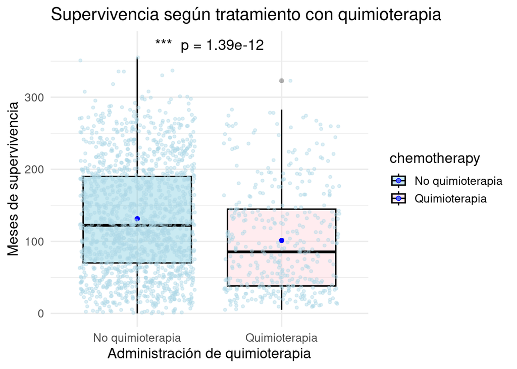

Figura 3. Boxplot de los meses de supervivencia según si los pacientes recibieron tratamiento con quimioterapia o no

# 4 Discusión

## 4.1 Análisis de edad de diagnostico vs tipo de cirugía

Tras analizar estadísticamente las variables edad de diagnóstico y tipo de cirugía, los resultados muestran una edad media de diagnóstico de 61,14 años. La mediana es de 61,82 años, lo que indica que existe una distribución equilibrada o simétrica, ya que no se observa una tendencia marcada hacia edades mas jóvenes o más avanzadas.

Esto refleja que aunque el diagnóstico de cáncer de mama es más frecuente en mujeres de mediana y mayor edad, también existen casos más precoces. Según lo descrito en diversos estudios científicos, la incidencia es mayor a partir de los 50 años.  
La edad media mínima de diagnóstico es de 21,93 años, mientras que la edad máxima es de 96,29 años. La desviación estándar es de 12,97, esto indica que la edad de diganóstico en mujeres varía entre las pacientes por lo que el cáncer de mama afecta en distintas etapas de la vida. La mayoría de los casos de diagnóstico se encuentran entre las edades de 48 y 74 años.

Por último, en el T-test se obtiene un valor de p=3.488 x 10 <sup>-8</sup>. Este dato es menor a 0,05, por lo que, **se rechaza la hipótesis nula y se acepta la alternativa**. Es decir, **existen diferencias significativas entre las edades correspondientes de las mujeres que se sometieron a mastectomía, en comparación con las que conservaron el pecho**.

## 4.2 Análisis del tamaño de tumor vs tipo de cirugía

En el T-test se obtiene un valor de p=2,2 x 10 <sup>-16</sup>. Este dato es menor a 0,05 lo que refleja que existen diferencias significativas entre el tamaño de los tumores y el tipo de cirugia realizada. Por lo tanto, **se rechaza la hipótesis nula y se acepta la hipótesis alternativa**: “**El tamaño medio del tumor de las mujeres con mastectomia es mayor al tamaño medio de las que conservaron el pecho**”.

En el gráfico se observa como las pacientes que conservan el pecho tienen tumores de menor tamaño que aquellas que se sometieron a mastectomía. La mediana en las pacientes que conservan el pecho es más baja indicando el menor tamaño de los tumores en este grupo.Sin embargo, en el grupo de mastectomía el tamaño es mayor. Además, en este último grupo se observan muchos valores atípicos (*outliers*) hacia tamaños grandes, lo que indica que cuando el tumor es muy grande se trata llevando a cabo una mastectomía. Por ende, hay una mayor probabilidad de someterse a una mastectomía en presencia de mayores tamaños de tumor.

## 4.3 Análisis de quimioterapia vs meses de supervivencia.

Tras analizar estadísticamente las variables quimioterapia y meses de supervivencia, los resultados muestran un valor medio de meses de supervivencia de 125,12. La mediana es de 115,61 meses, lo que indica que existe una distribución no simétrica sesgada a la derecha. Esto se debe a que la media es mayor a la mediana.

La desviación estándar es de 76,33, esto indica que existe una dispersión bastante grande de los datos. La mayor parte de los valores se encuentran entre 48 y 201 meses de supervivencia. El valor mínimo de meses de supervivencia tras el diagnóstico es de 0 meses, mientras que el valor máximo es de 355,2 meses.

En el T-test se obtiene un valor de p=1,39 x 10 <sup>-12</sup>. Este dato es menor a 0,05 lo que refleja que existen diferencias significativas entre la administración o no de quimioterapia y los meses de supervivencia tras el diagnóstico. Por lo tanto, **se rechaza la hipótesis nula y se acepta la hipótesis alternativa**: ” **Los meses de supervivencia están relacionados significativamente con la administración de quimioterapia**”.

En el gráfico se observa como las pacientes que se han sometido a quimioterapia sobreviven menos meses que aquellas que no se han sometido a quimioterapia. Esto se debe a que aquellas mujeres que recibieron quimioterapia estaban en etapas más avanzadas de la enfermedad. La mediana en las pacientes con tratamiento de quimioterapia es más baja si comparamos con las que no se han sometido a quimioterapia, en las que la mediana de supervivencia es claramante mayor. En la representación de la cohorte de las mujeres tratadas con quimioterapia se observa un outlier, es decir, un valor muy alejado del resto que no se integra en la representación.

# 5 Conclusiones

Los resultados obtenidos a partir de los análisis estadísticos, nos indican que el tipo de cirugía está relacionado principalmente con el tamaño del tumor, y en menor medida con la edad de diagnóstico. Por consiguiente, la supervivencia se asocia con la administración de quimioterapia, en donde aquellas pacientes que recibieron el tratamiento mostraron menor superviviencia debido a que posiblemente recurrieron a quimioterapia por encontrarse en un estado más avanzado del cáncer.

# 6 Referencias

Se han utilizado los datos de METABRIC (Alharbi 2020)

Alharbi, Raghad. 2020. “Breast Cancer Gene Expression Profiles (METABRIC) Dataset.” https://www.kaggle.com/datasets/raghadalharbi/breast-cancer-gene-expression-profiles-metabric/data.

R Core Team. 2024. *R: A Language and Environment for Statistical Computing*. https://www.R-project.org/.

Wickham, Hadley. 2016. *Ggplot2: Elegant Graphics for Data Analysis*. Springer-Verlag New York. https://ggplot2.tidyverse.org.

Wickham, Hadley, Winston Chang, Lionel Henry, Thomas Lin Pedersen, Kohske Takahashi, Claus Wilke, Kara Woo, Hiroaki Yutani, Dewey Dunnington, and Teun van den Brand. 2025. *Ggplot2: Create Elegant Data Visualisations Using the Grammar of Graphics*. https://ggplot2.tidyverse.org.

Wickham, Hadley, Romain François, Lionel Henry, Kirill Müller, and Davis Vaughan. 2023. *Dplyr: A Grammar of Data Manipulation*. https://dplyr.tidyverse.org.

Xie, Yihui. 2014. “Knitr: A Comprehensive Tool for Reproducible Research in R.” In *Implementing Reproducible Computational Research*, edited by Victoria Stodden, Friedrich Leisch, and Roger D. Peng. Chapman; Hall/CRC.

———. 2015. *Dynamic Documents with R and Knitr*. 2nd ed. Boca Raton, Florida: Chapman; Hall/CRC. https://yihui.org/knitr/.

———. 2025. *Knitr: A General-Purpose Package for Dynamic Report Generation in r*. https://yihui.org/knitr/.